# San Francisco Crime Data Story

## Crime in San Francisco

San Fransisco has a huge drug/narcotics problem, as stated by the government of San Fransisco, “Drug overdoses are a public health crisis nationally and in San Francisco.{Cite:sf.gov}”. Therefore we find interesting and most importantly relevant to investigate the criminal drug history of San Fransisco. The data we wish to investigate has been compiled from 2003-2024, by the city of San Fransisco, and includes many different types of crimes, but our analysis will focus on drugs/narcotics. It is important to note that this dataset documents reported incidents and does not reflect criminal convictions. An incident report indicates that an event was reported to and documented by the police, but it does not imply that the reported activity resulted in an arrest, charge, or conviction. Therefore the data should not be interpreted as definitive evidence of criminal activity.

## Drugs And Narcotic Trends Over Time

First, to get a sense of how drug/narcotic incidents have changed over time, we start by looking at a bar plot.

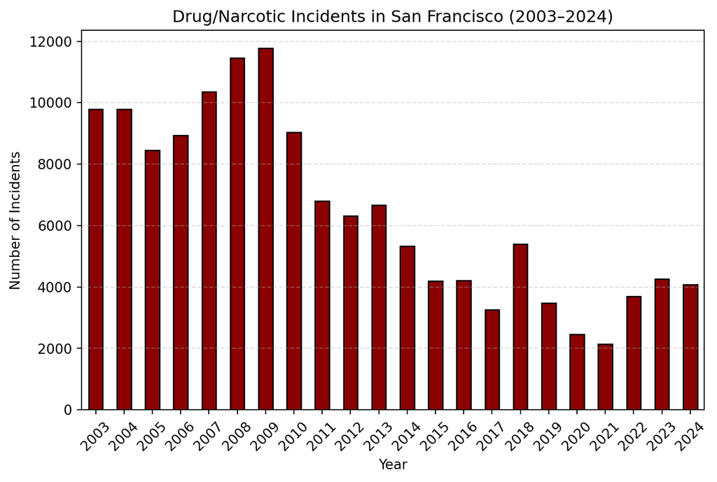

```python
import pandas as pd
import matplotlib.pyplot as plt

df = pd.read_csv(r"C:\Users\mich0\Downloads\merged_data.csv")
df = df[(df['Year'] >= 2003) & (df['Year'] <= 2024)]
category_col = 'Incident Category' if 'Incident Category' in df.columns else 'Category'
df = df[df[category_col].str.upper().str.contains("DRUG/NARCOTIC", na=False)]

year_counts = df['Year'].value_counts().sort_index()

plt.figure().set_figwidth(7.4)
year_counts.plot(kind="bar", color="darkred", edgecolor="black")
plt.title("Drug/Narcotic Incidents in San Francisco (2003–2024)")
plt.xlabel("Year")
plt.ylabel("Number of Incidents")
plt.xticks(rotation=45)
plt.grid(axis='y', linestyle='--', alpha=0.4)
plt.tight_layout()
plt.show()
```

**Figure 1.** *The plot above shows the annual number of drugs and narcotics incidents (y-axis) in San Francisco from the year 2003 to 2024 (x-axis). We see a downward trend of incidents throughout the years past 2009 where the peak happened.*

The first thing we notice is that shortly after the turn of the millennium, drug incidents steadily increased from 2005 to 2009, reaching their highest point in 2009. After that peak, there’s a fairly consistent decline in drug incidents in the following years. Based on available research, there doesn’t appear to be any specific legislative change in 2009—unlike the drug reform measures that came later in 2010 and 2016. So, there’s no definitive answer as to why the downward trend began that year. However, one possible explanation could lie in broader economic factors at the time. In 2008, the financial crisis hit, triggering the Great Recession. It is possible that the decline in drug incidents starting in 2009 could be linked to the economic downturn, simply people may have had less disposable income, making it harder to afford narcotics.

It would now make sense to observe the trends of the data around the major legislative acts concerning drug use.

In september 2010, Arnold Schwarzenegger, in his capacity as governor signed a bill reducing possession of under 1 ounce from a misdemeanour to a civil infraction{Cite: Wikipedia} (meaning you cannot be jailed, for possession of under 1 ounce of cannabis). This might help explain the relative stagnation in incident numbers between 2011-2013. As the penalties for possession were reduced, it may have encouraged a rise in usage. However, since cannabis hadn’t been fully legalised yet, being caught with even under an ounce could still result in an incident report.

Furthermore, as cannabis became decriminalised, it is likely that in the years following the major reforms, the drugs involved in the incident reports were increasingly ‘harder’ drugs.

The next major shift in drug policy came in 2016 with the passing of the “Adult Use of Marijuana Act,” which expanded the legalisation of cannabis for personal use and cultivation (Source: Wikipedia). The law officially went into effect in 2018. While it did not technically decriminalise all drug use, it did lead to a notable change in enforcement; police often stopped intervening, even when use was visible in public, and prosecutors rarely pursued charges for possession or personal use (Source: NY Times).

However, when looking at the data, there doesn’t appear to be any significant change in trends after 2018. Interestingly, none of the major drug policy reforms, that we have discussed, seem to have caused a noticeable shift in the overall pattern of reported incidents.

The decline in drug incidents from 2009 onward likely reflects a broader cultural shift rather than specific legislation. Changing attitudes toward drug use, from citizen and police could explain the reduction. As mentioned, despite drug use technically remaining illegal, police have largely stopped intervening, which likely means fewer incident reports are being filed as a result.

## Heatmap over San Francisco of Drug/Narcotic Incidents

```python
import pandas as pd
import folium
from folium.plugins import HeatMapWithTime
from IPython.display import display

# Load data
df = pd.read_csv(r"C:\Users\mich0\Downloads\merged_data.csv")

# Determine correct category column
category_col = 'Incident Category' if 'Incident Category' in df.columns else 'Category'

# Filter for Drug/Narcotic incidents
df_filtered = df[(df[category_col].str.upper().str.contains('DRUG/NARCOTIC', na=False)) &
                 (df['Year'].between(2003, 2024))].copy()

# Drop rows with missing location or month/year
df_filtered = df_filtered[['Latitude', 'Longitude', 'Month', 'Year']].dropna()

# Validate coordinates
df_filtered = df_filtered[
    (df_filtered['Latitude'].between(-90, 90)) &
    (df_filtered['Longitude'].between(-180, 180))
]

# Handle case where Month column has string names (like 'January')
month_mapping = {
    "January": 1, "February": 2, "March": 3, "April": 4,
    "May": 5, "June": 6, "July": 7, "August": 8,
    "September": 9, "October": 10, "November": 11, "December": 12
}
month_names = list(month_mapping.keys())

# Convert Month column to numeric (handles both string names and numeric)
if df_filtered['Month'].dtype == 'object':
    df_filtered['MonthNum'] = df_filtered['Month'].map(month_mapping)
else:
    df_filtered['MonthNum'] = df_filtered['Month'].astype(int)

# Drop rows with unrecognized month
df_filtered = df_filtered.dropna(subset=['MonthNum'])

# Convert types
df_filtered['MonthNum'] = df_filtered['MonthNum'].astype(int)
df_filtered['Year'] = df_filtered['Year'].astype(int)

# Sort by time
df_filtered = df_filtered.sort_values(['Year', 'MonthNum'])

# Build heatmap data and time labels
heat_data = []
time_labels = []

for year in range(2003, 2025):
    for month_num in range(1, 13):
        month_data = df_filtered[
            (df_filtered['Year'] == year) &
            (df_filtered['MonthNum'] == month_num)
        ]
        coords = month_data[['Latitude', 'Longitude']].values.tolist()
        heat_data.append(coords)
        time_labels.append(f"{month_names[month_num - 1]} {year}")

# Create the  heatmap
base_map = folium.Map(location=[37.76, -122.42],
                      zoom_start=11.5,
                      zoom_control=0,
                      scrollWheelZoom=True,
                      dragging=1)

# Add time series heatmap of SF
HeatMapWithTime(
    heat_data,
    index=time_labels,
    auto_play=False,
    max_opacity=0.7,
    radius=10,
    min_opacity=0.1,
    gradient={0.2: 'blue', 0.4: 'lime', 0.6: 'orange', 0.8: 'darkred'},
    display_index=True,
    use_local_extrema=True,
    blur=1,
    name="Drug/Narcotic Incidents"
).add_to(base_map)

# Display in notebook
display(base_map)
```

Make this Notebook Trusted to load map: File -> Trust Notebook

[interactive chart not shown]

**Figure 2.** *Heatmap of Drug/Narcotic incidents in San Francisco from 2003 to 2024 throughout each month which changes for each frame. The more red the higher frequency of incidencts and likewise more towards blue for lower occurances of Drug/Narcotic incidents.*

Firstly, by observing the map, we again see that there is a steady decrease in drugs incidents in San Fransisco, this tracks with the bar plot above. From 2003-2009, we notice a clear centralisation of the drug incidents. The centralisation is around the Union square, which is the central shopping district of San Fransisco. The heat map corresponds with the population density map of San Fransisco, made by statisticalatlas {Cite: Statistical atlas}. This could indicate, that drug incidents happen closely to the drug possessors residences.

Furthermore, when looking at the time series heat maps—and keeping in mind that the first major drug reform was passed in 2010—we can see that as cannabis possession became decriminalised, drug incident reports became more spread out across the city. However, there remains a noticeable concentration near Union Square. If our previous statement is true, that drug incidents happen at or near peoples residences, then the continued concentration near Union Square suggests that this area may not just reflect residential drug use, but also public consumption or street-level drug activity.

An interesting observation from the heat maps is that incidents are concentrated almost entirely in urban or developed areas, with very few occurring in public parks. This pattern could support the theory that drug possession is more closely linked to residential zones. However, it may also reflect a bias in enforcement, as it is likely easier for police to patrol and detect drug activity in densely populated areas compared to large, less-monitored parks.

## Crime Profile Comparison

```python
import pandas as pd
from bokeh.models import ColumnDataSource, Select, Div, CustomJS
from bokeh.layouts import column, row
from bokeh.io import output_file, save

# Load your merged dataset
df = pd.read_csv(r"C:\Users\mich0\Downloads\merged_data.csv")

# Normalize column name
if 'Incident Category' in df.columns:
    df = df.rename(columns={'Incident Category': 'Category'})

df = df.dropna(subset=['Category', 'Year', 'Month'])

# Month mapping logic
month_mapping = {
    "January": 1, "February": 2, "March": 3, "April": 4,
    "May": 5, "June": 6, "July": 7, "August": 8,
    "September": 9, "October": 10, "November": 11, "December": 12
}
reverse_month_mapping = {v: k for k, v in month_mapping.items()}

# Handle both string and numeric months
if df['Month'].dtype == object:
    df['Month'] = df['Month'].str.strip().str.title().map(month_mapping)
else:
    df['Month'] = pd.to_numeric(df['Month'], errors='coerce')

df['Year'] = pd.to_numeric(df['Year'], errors='coerce')
df = df.dropna(subset=['Month', 'Year'])
df['Month'] = df['Month'].astype(int)
df['Year'] = df['Year'].astype(int)

# Get categories
crime_categories = sorted(df['Category'].str.upper().unique())

# Precompute statistics
crime_stats = {}
for cat in crime_categories:
    subset = df[df['Category'].str.upper() == cat]
    if subset.empty:
        continue
    top_district = subset['PdDistrict'].mode().iloc[0] if 'PdDistrict' in subset and not subset['PdDistrict'].isna().all() else "Unknown"
    top_time = subset['TimeOfDay'].mode().iloc[0] if 'TimeOfDay' in subset and not subset['TimeOfDay'].isna().all() else "Unknown"
    peak_year = subset['Year'].value_counts().idxmax()
    avg_monthly = int(subset.groupby(['Year', 'Month']).size().mean())

    # New: Month with highest average incidents
    monthly_avg = subset.groupby('Month').size().div(subset['Year'].nunique())
    month_with_highest_avg = reverse_month_mapping.get(monthly_avg.idxmax(), "Unknown")

    crime_stats[cat] = {
        "Top District": top_district,
        "Most Active Time": top_time,
        "Peak Year": peak_year,
        "Monthly Avg": avg_monthly,
        "Month with Highest Avg. Incidents": month_with_highest_avg
    }

# Bokeh widgets and layout
select1 = Select(title="Crime Type 1", value="DRUG/NARCOTIC", options=crime_categories)
select2 = Select(title="Crime Type 2", value="ASSAULT", options=crime_categories)

div1 = Div(width=400, height=260)
div2 = Div(width=400, height=260)

callback = CustomJS(args=dict(stats=crime_stats, s1=select1, s2=select2, d1=div1, d2=div2), code="""
function renderCard(cat) {
    const data = stats[cat];
    if (!data) return `<div style='border:2px solid #555;padding:10px;border-radius:8px;background:#f9f9f9;'>
        <b>${cat}</b><br>No data available.</div>`;
    return `<div style='border:2px solid #555;padding:15px;border-radius:10px;background:#fdfdfd;font-size:15px;'>
        <h2 style='margin:0 0 10px;'>${cat}</h2>
        <b>Top District:</b> ${data["Top District"]}<br>
        <b>Most Active Time:</b> ${data["Most Active Time"]}<br>
        <b>Peak Year:</b> ${data["Peak Year"]}<br>
        <b>Avg/Month:</b> ${data["Monthly Avg"]}<br>
        <b>Month with Highest Avg. Incidents:</b> ${data["Month with Highest Avg. Incidents"]}
    </div>`;
}
d1.text = renderCard(s1.value);
d2.text = renderCard(s2.value);
""")

select1.js_on_change('value', callback)
select2.js_on_change('value', callback)

layout = column(
    row(select1, select2),
    row(div1, div2)
)


output_file("crime_profile_comparison.html")
file_path = save(layout)
```

[interactive chart not shown]

**Figure 3.** *This figure displays an interactive profile comparison of the different incident types and their corresponding meta-data, showing top discrict a certain crime happens, most active hour of the day, peak year, avg monthly incidents and the month with highest avg incidents.*

Through the interactive plot it is easy to get a strong overview over drug/narcotic incidents metadata, compared to the other incident types in the dataset. For example, drug incidents are together with trespassing the only two incident attributes, which happens before 17.00 o’clock. One might have stated a hypothesis, that drug usage/possession, would be a night activity, but here the data clearly shows that the most active time of day is 14.00 o’clock. Again just as with the parks this might be a bias, as drug usage is easier to notice during the day, then it is at night. As mentioned earlier the peak year for drug incidents were 2009. By reviewing all incident types, there are non that peaked later than 2015, this supports the theory, that there is an overall cultural shift reducing crime/incidents, as all types of incidents peaked over a decade ago. There are only three other incident categories that peaked earlier than drugs/narcotics, those were; Burglary, Prostitution and Vehicle theft. There are comparatively, to the other incident types a somewhat high monthly volume of incidents, only being ‘beaten’ (pun intended), by assault and vehicle theft.

By Observing figure 3, it is also quite clear that march is the month, for which most incidents of distinctive incidents occur, with seven (including drug/narcotics), out of 12 incident types, having highest average number of incidents in march. Drug/narcotics is also the only incident type that is most active in the Tenderloin, an area close to Union Square. This supports the theory that street-level drug dealing or commercial activity may be taking place there. Unlike other incident types, drug-related offenses uniquely involve a clear commercial element, which could explain this concentration.

### References

1. [San Francisco Overdose & Treatment Data – 2023](https://www.sf.gov/resource--2023--drug-overdose-and-treatment-data-and-reports#)  
   *A public dashboard providing drug overdose trends and treatment-related data in SF.*
2. [Drug Policy of California – Wikipedia](https://en.wikipedia.org/wiki/Drug_policy_of_California)  
   *An overview of historical and recent legislative actions regarding drug policy in the state.*
3. [The Upshot – NYT: San Francisco Drug Crisis (2024)](https://www.nytimes.com/2024/01/31/upshot/san-francisco-drug-crisis.html#:~:text=What%20San%20Francisco%20did%3A%20California’s,for%20drug%20possession%20or%20use.)  
   *Analysis of California’s decriminalization efforts and its visible impact in SF.*
4. [Statistical Atlas: San Francisco County Demographics](https://statisticalatlas.com/county/California/San-Francisco-County/Population)  
   *Visualizations and detailed data on population, income, education, and more.*